# STAT 420: Homework 7

## Exercise 3 (Writing Functions)

**(a)** Write a function that takes as input a model object (variable) fit via `lm()` and outputs a fitted versus residuals plot. Also create arguments `pointcol` and `linecol` which control the point and line colors respectively. Code the plot to add a horizontal line at $y = 0$ and label the $x$-axis “Fitted” and the $y$-axis “Residuals”.

```r
pointcol = c("darkgreen")
linecol = c("deepskyblue")

myResidFunc = function(myModel,pointcol,linecol){
  plot(fitted(myModel),resid(myModel),col=pointcol,xlab="Fitted",ylab="Residuals",main = "Fitted v Residuals")
abline(h=0,col=linecol,lwd=2)
}
```

**(b)** Write a function that takes as input a model fit via `lm()` plots a Normal Q-Q plot of the residuals. Also create arguments `pointcol` and `linecol` which control the point and line colors respectively. Code the plot to add the line from `qqline()`.

```r
pointcol = c("darkgreen")
linecol = c("deepskyblue")

myNormalFunct = function(myModel,pointcol,linecol){
  qqnorm(resid(myModel), main = "Normal Q-Q Plot", col = pointcol)
  qqline(resid(myModel), col = linecol, lwd = 2)
}
```

**(c)** Test your two functions above on the `test_fit` model. For both functions, specify point and line colors that are not black.

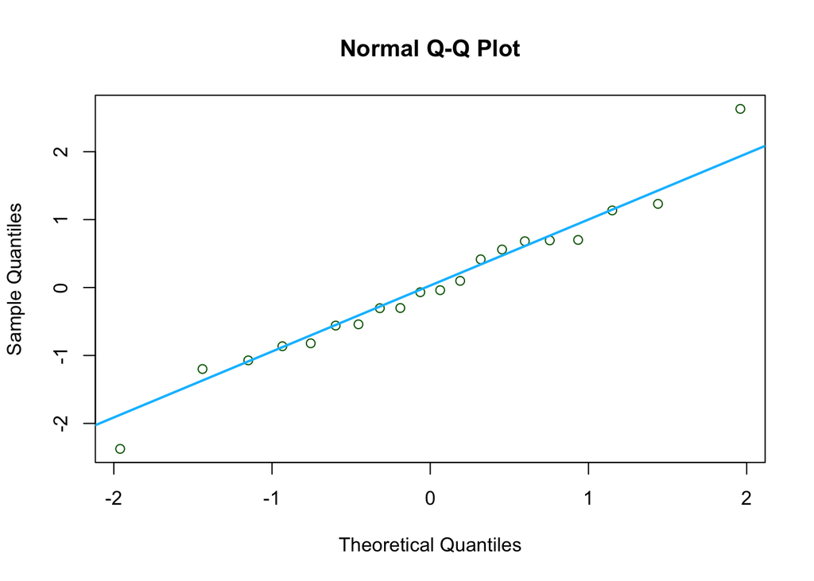

```r
set.seed(120168)
test_data = data.frame(x = runif(20, 0, 10),
                       y = rep(0, 20))
test_data$y = 5 + 2 * test_data$x + rnorm(20)
test_fit = lm(y ~ x, data = test_data)

pointcol = c("darkgreen")
linecol = c("deepskyblue")

myNormalFunct(test_fit,pointcol,linecol)
```

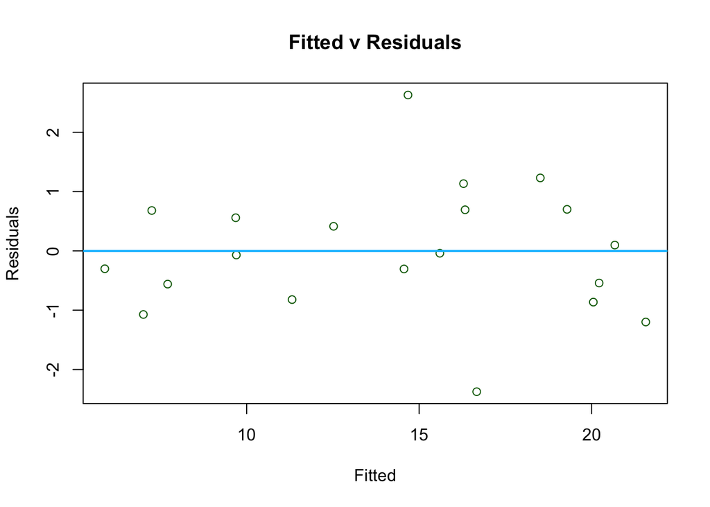

```r
myResidFunc(test_fit,pointcol,linecol)
```

## Exercise 4 (Why Bother with Assumptions?)

**Why** do we care about violations of assumptions? One key reason is that the distributions of the parameters that we have used are all reliant on these assumptions. When the assumptions are violated, the distributional results are not correct, so are tests are garbage. **Garbage In, Garbage Out!**

Consider the following setup that we will use for the remainder of the exercise. We choose a sample size of 50.

```r
n = 50
set.seed(123)
x_1 = runif(n, 0, 10)
x_2 = runif(n, -5, 5)
```

Consider the model,

$$Y = 2 + 1 x_1 + 0 x_2 + \epsilon.$$

That is,

- $\beta_0$ = 2,
- $\beta_1$ = 1,
- $\beta_2$ = 0.

We now simulate `y_1` in a manner that doesn’t violate any assumptions, which we verify. In this case $\epsilon \sim N(0, 1).$

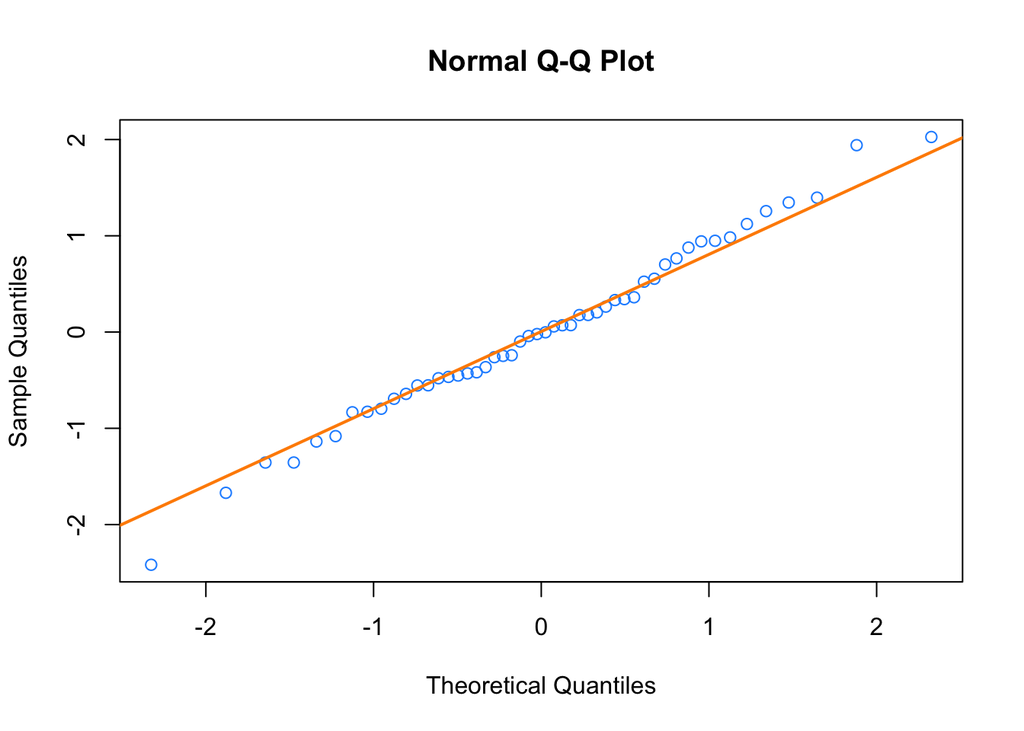

```r
y_1   = 2 + x_1 + 0 * x_2 + rnorm(n)
fit_1 = lm(y_1 ~ x_1 + x_2)
qqnorm(resid(fit_1), col = "dodgerblue")
qqline(resid(fit_1), col = "darkorange", lwd = 2)
```

```r
shapiro.test(resid(fit_1))
```

```
##
##  Shapiro-Wilk normality test
##
## data:  resid(fit_1)
## W = 0.99118, p-value = 0.9698
```

Then, we simulate `y_2` in a manner that **does** violate assumptions, which we verify. In this case $\epsilon \sim N(0, \sigma = |x_2|).$

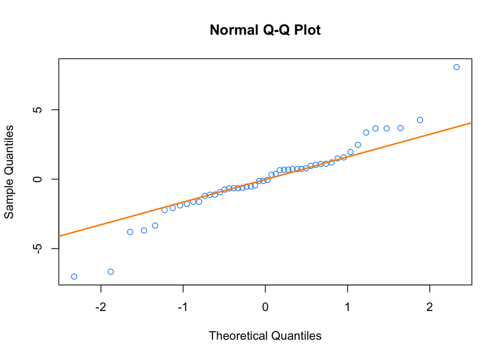

```r
y_2   = 2 + x_1 + 0 * x_2 + rnorm(n, 0, abs(x_2))
fit_2 = lm(y_2 ~ x_1 + x_2)
qqnorm(resid(fit_2), col = "dodgerblue")
qqline(resid(fit_2), col = "darkorange", lwd = 2)
```

```r
shapiro.test(resid(fit_2))
```

```
##
##  Shapiro-Wilk normality test
##
## data:  resid(fit_2)
## W = 0.94718, p-value = 0.02615
```

**(a)** Use the following code after changing `uin` to your UIN.

```r
num_sims = 1000
p_val_1 = rep(0, num_sims)
p_val_2 = rep(0, num_sims)
uin = 667850670
set.seed(uin)
```

Repeat the above process of generating `y_1` and `y_2` as defined above, and fit models with each as the response `1000` times. Each time, store the p-value for testing,

$$\beta_2 = 0,$$

using both model, in the appropriate variables defined above. (You do not need to use a data frame as we have in the past.)

```r
num_sims = 1000
p_val_1 = rep(0, num_sims)
p_val_2 = rep(0, num_sims)
uin = 667850670
set.seed(uin)

x = runif(n,0,10)
y = runif(n,-5,5)
sim = 0
for(sim in sim:num_sims){
  fit1 = lm(2 * x + 0*y + rnorm(50) ~ x+y)
  fit2 = lm(2 * x + 0*y + rnorm(50,0,abs(y)) ~ x+y)
  p_val_1[sim] = shapiro.test(resid(fit1))[2]
  p_val_2[sim] = shapiro.test(resid(fit2))[2]
}
```

**(b)** What proportion of the `p_val_1` values are less than 0.05? Less than 0.10? What proportion of the `p_val_2` values are less than 0.05? Less than 0.10? Briefly explain these results.

```r
#less than 0.5
mean(p_val_1 < 0.05)
```

```
## [1] 0.041
```

```r
#less than 0.05
mean(p_val_2 < 0.05)
```

```
## [1] 0.734
```

```r
#less than .10
mean(p_val_1 < 0.10)
```

```
## [1] 0.094
```

```r
#less than .10
mean(p_val_2 < 0.10)
```

```
## [1] 0.806
```